# Final Project in Time Series Analysis: forecasting Google trends with VAR AND ARIMA models

3. **Let’s determine p and q**

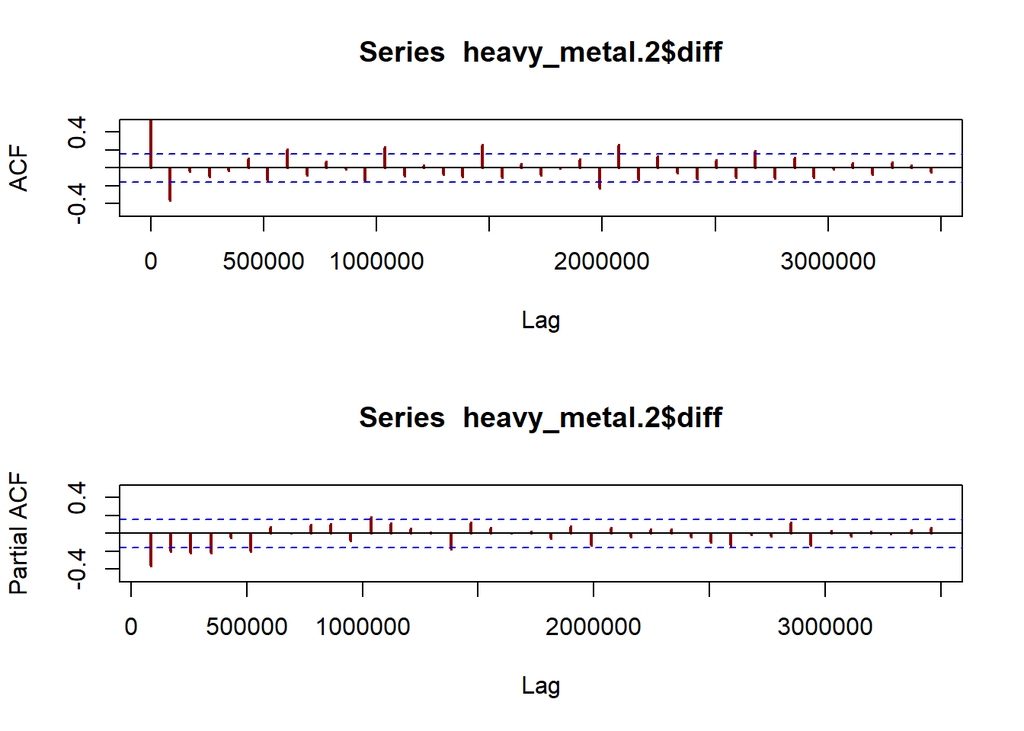

```r
heavy_metal.2$diff <- diff(heavy_metal.2)

par(mfrow = c(2, 1))
acf(heavy_metal.2$diff,
    lag.max = 40,
    ylim = c(-0.5, 0.5),
    lwd = 2,
    col = "darkred",
    na.action = na.pass)
pacf(heavy_metal.2$diff,
     lag.max = 40,
     ylim=c(-0.5,0.5),
     lwd = 2,
     col = "darkred",
     na.action = na.pass)
```

4. **Let’s still start with ARIMA(1,1,1) (p=q=1)**

```r
arima_111_hm <- Arima(heavy_metal.2$heavy_metal,order=c(1,1,1),include.constant = TRUE)
```

5. **Check parameters**

```r
coeftest(arima_111_hm)
```

```
##
## z test of coefficients:
##
##        Estimate Std. Error  z value  Pr(>|z|)
## ar1    0.174804   0.111672   1.5653    0.1175
## ma1   -0.716034   0.070656 -10.1341 < 2.2e-16 ***
## drift -0.457570   0.111958  -4.0870  4.37e-05 ***
## ---
## Signif. codes:  0 '***' 0.001 '**' 0.01 '*' 0.05 '.' 0.1 ' ' 1
```

6. **Diagnostics: let’s check whether there is autocorrelation in the residuals**

plot:

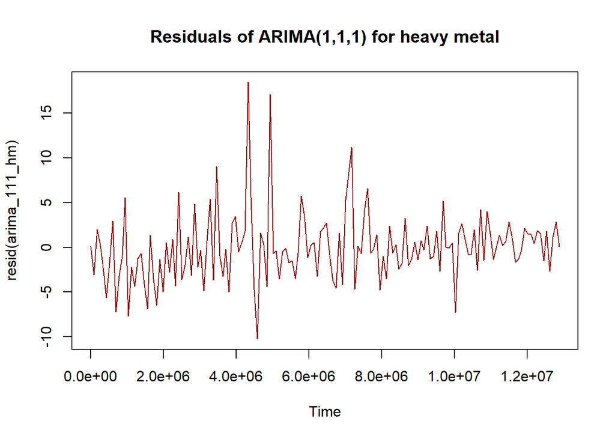

```r
plot(resid(arima_111_hm),
     col="darkred",
     main="Residuals of ARIMA(1,1,1) for heavy metal")
```

This seems like white noise.

ACF and PACF:

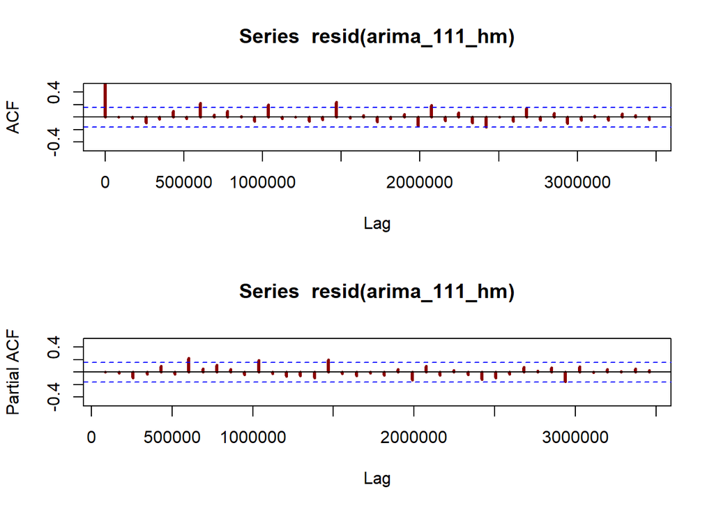

```r
par(mfrow = c(2, 1))
acf(resid(arima_111_hm),
    lag.max = 40,
    ylim = c(-0.5, 0.5),
    lwd = 3, col = "darkred",
    na.action = na.pass)
pacf(resid(arima_111_hm),
     lag.max =40,
     ylim = c(-0.5, 0.5),
     lwd =3, col = "darkred",
     na.action = na.pass)
```

Some lags are still significant and many are on the edge.

Ljung-Box test:

```r
Box.test(resid(arima_111_hm),type = c("Ljung-Box"),lag = 5)
```

```
##
##  Box-Ljung test
##
## data:  resid(arima_111_hm)
## X-squared = 3.0664, df = 5, p-value = 0.6898
```

p-value is larger than 0.05, so ARIMA(1,1,1) can be considered.

7. **Let’s try other models.**
- ARIMA(1,1,2)

```r
arima_112_hm <- Arima(heavy_metal.2$heavy_metal,order=c(1,1,2),include.constant = TRUE)
arima_112_hm
```

```
## Series: heavy_metal.2$heavy_metal
## ARIMA(1,1,2) with drift
##
## Coefficients:
##          ar1      ma1      ma2    drift
##       0.0911  -0.6297  -0.0573  -0.4579
## s.e.  0.3956   0.3907   0.2521   0.1120
##
## sigma^2 = 15.69:  log likelihood = -414.73
## AIC=839.45   AICc=839.87   BIC=854.47
```

```r
coeftest(arima_112_hm)
```

```
##
## z test of coefficients:
##
##        Estimate Std. Error z value  Pr(>|z|)
## ar1    0.091148   0.395618  0.2304    0.8178
## ma1   -0.629731   0.390704 -1.6118    0.1070
## ma2   -0.057299   0.252074 -0.2273    0.8202
## drift -0.457916   0.111993 -4.0888 4.336e-05 ***
## ---
## Signif. codes:  0 '***' 0.001 '**' 0.01 '*' 0.05 '.' 0.1 ' ' 1
```

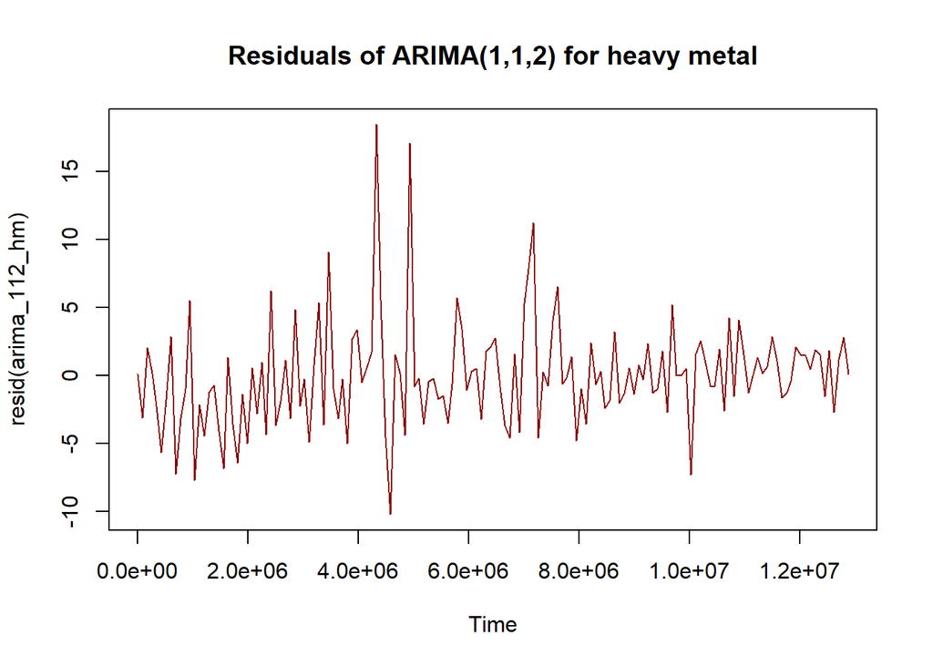

```r
plot(resid(arima_112_hm),
     col="darkred",
     main="Residuals of ARIMA(1,1,2) for heavy metal")
```

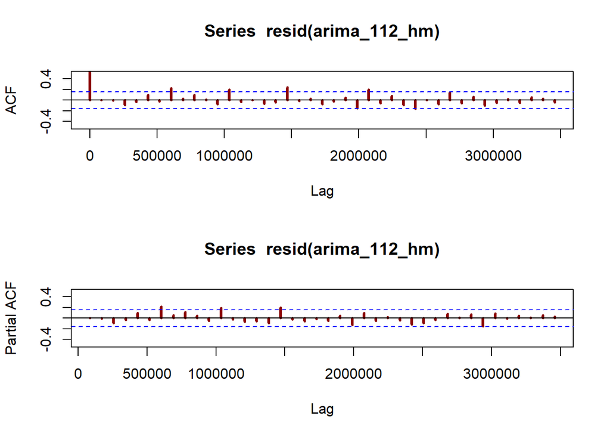

```r
par(mfrow = c(2, 1))
acf(resid(arima_112_hm),
    lag.max = 40,
    ylim = c(-0.5, 0.5),
    lwd = 3, col = "darkred",
    na.action = na.pass)
pacf(resid(arima_112_hm),
     lag.max =40,
     ylim = c(-0.5, 0.5),
     lwd =3, col = "darkred",
     na.action = na.pass)
```

```r
Box.test(resid(arima_112_hm),type = c("Ljung-Box"),lag = 6)
```

```
##
##  Box-Ljung test
##
## data:  resid(arima_112_hm)
## X-squared = 3.1616, df = 6, p-value = 0.7883
```

arima_112_hm could work.

- ARIMA(3,1,1)

```r
arima_311_hm <- Arima(heavy_metal.2$heavy_metal,order=c(3,1,1),include.constant = TRUE)
arima_311_hm
```

```
## Series: heavy_metal.2$heavy_metal
## ARIMA(3,1,1) with drift
##
## Coefficients:
##          ar1      ar2      ar3      ma1    drift
##       0.0613  -0.0712  -0.1474  -0.6020  -0.4604
## s.e.  0.1391   0.0991   0.0926   0.1206   0.1107
##
## sigma^2 = 15.53:  log likelihood = -413.51
## AIC=839.02   AICc=839.62   BIC=857.05
```

```r
coeftest(arima_311_hm)
```

```
##
## z test of coefficients:
##
##        Estimate Std. Error z value  Pr(>|z|)
## ar1    0.061281   0.139097  0.4406    0.6595
## ar2   -0.071185   0.099092 -0.7184    0.4725
## ar3   -0.147411   0.092632 -1.5914    0.1115
## ma1   -0.602000   0.120628 -4.9906 6.021e-07 ***
## drift -0.460382   0.110660 -4.1603 3.178e-05 ***
## ---
## Signif. codes:  0 '***' 0.001 '**' 0.01 '*' 0.05 '.' 0.1 ' ' 1
```

The parameters of a1 and ar2 and ar3 are insignificant, so let’s remove them.

```r
arima_311_hm.2 <- Arima(heavy_metal.2$heavy_metal,order=c(3,1,1),
                       fixed=c(0,0,0,NA,NA),
                       include.constant = TRUE)
coeftest(arima_311_hm.2)
```

```
##
## z test of coefficients:
##
##        Estimate Std. Error z value  Pr(>|z|)
## ma1   -0.627764   0.069118 -9.0825 < 2.2e-16 ***
## drift -0.459381   0.121528 -3.7800 0.0001568 ***
## ---
## Signif. codes:  0 '***' 0.001 '**' 0.01 '*' 0.05 '.' 0.1 ' ' 1
```

[figure not shown]

```r
plot(resid(arima_311_hm.2),
     col="darkred",
     main="Residuals of ARIMA(3,1,1) without a1 and ar2 for heavy metal")
```

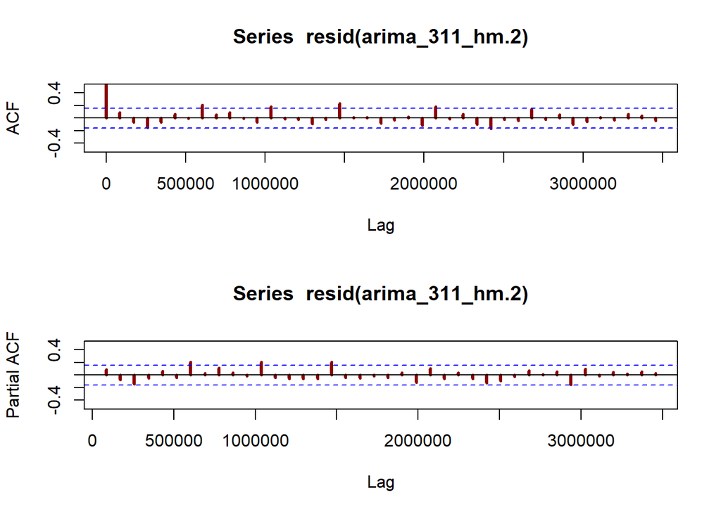

```r
par(mfrow = c(2, 1))
acf(resid(arima_311_hm.2),
    lag.max = 40,
    ylim = c(-0.5, 0.5),
    lwd = 3, col = "darkred",
    na.action = na.pass)
pacf(resid(arima_311_hm.2),
     lag.max =40,
     ylim = c(-0.5, 0.5),
     lwd =3, col = "darkred",
     na.action = na.pass)
```

```r
Box.test(resid(arima_311_hm.2),type = c("Ljung-Box"),lag = 5)
```

```
##
##  Box-Ljung test
##
## data:  resid(arima_311_hm.2)
## X-squared = 6.8271, df = 5, p-value = 0.2338
```

ARIMA(3,1,1) without ar1 ar2 and ar3 could work.

- ARIMA(3,1,3)

```r
arima_313_hm <- Arima(heavy_metal.2$heavy_metal,order=c(3,1,3),include.constant = TRUE)
arima_313_hm
```

```
## Series: heavy_metal.2$heavy_metal
## ARIMA(3,1,3) with drift
##
## Coefficients:
##          ar1      ar2      ar3      ma1     ma2     ma3    drift
##       0.8619  -0.1370  -0.1847  -1.4391  0.5260  0.1056  -0.4669
## s.e.  0.5606   0.6101   0.2112   0.5631  0.9206  0.4292   0.1311
##
## sigma^2 = 15.24:  log likelihood = -411.2
## AIC=838.4   AICc=839.43   BIC=862.44
```

```r
coeftest(arima_313_hm)
```

```
##
## z test of coefficients:
##
##       Estimate Std. Error z value  Pr(>|z|)
## ar1    0.86190    0.56059  1.5375 0.1241748
## ar2   -0.13696    0.61006 -0.2245 0.8223600
## ar3   -0.18465    0.21121 -0.8743 0.3819717
## ma1   -1.43909    0.56309 -2.5557 0.0105981 *
## ma2    0.52602    0.92058  0.5714 0.5677294
## ma3    0.10559    0.42919  0.2460 0.8056615
## drift -0.46693    0.13108 -3.5621 0.0003679 ***
## ---
## Signif. codes:  0 '***' 0.001 '**' 0.01 '*' 0.05 '.' 0.1 ' ' 1
```

The parameters of ar2,ma2,ma3 are insignificant, let’e remove them.

```r
arima_313_hm.2 <- Arima(heavy_metal.2$heavy_metal,
                        order=c(3,1,3),
                        fixed=c(NA,0,NA,NA,0,0,NA),
                        include.constant = TRUE)
coeftest(arima_313_hm.2)
```

```
##
## z test of coefficients:
##
##        Estimate Std. Error z value  Pr(>|z|)
## ar1    0.101783   0.119908  0.8488    0.3960
## ar3   -0.132798   0.091379 -1.4533    0.1461
## ma1   -0.649604   0.088314 -7.3556 1.900e-13 ***
## drift -0.458937   0.109677 -4.1844 2.859e-05 ***
## ---
## Signif. codes:  0 '***' 0.001 '**' 0.01 '*' 0.05 '.' 0.1 ' ' 1
```

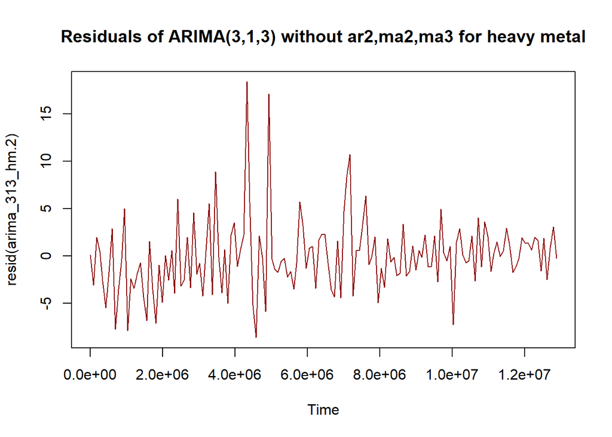

```r
plot(resid(arima_313_hm.2),
     col="darkred",
     main="Residuals of ARIMA(3,1,3) without ar2,ma2,ma3 for heavy metal")
```

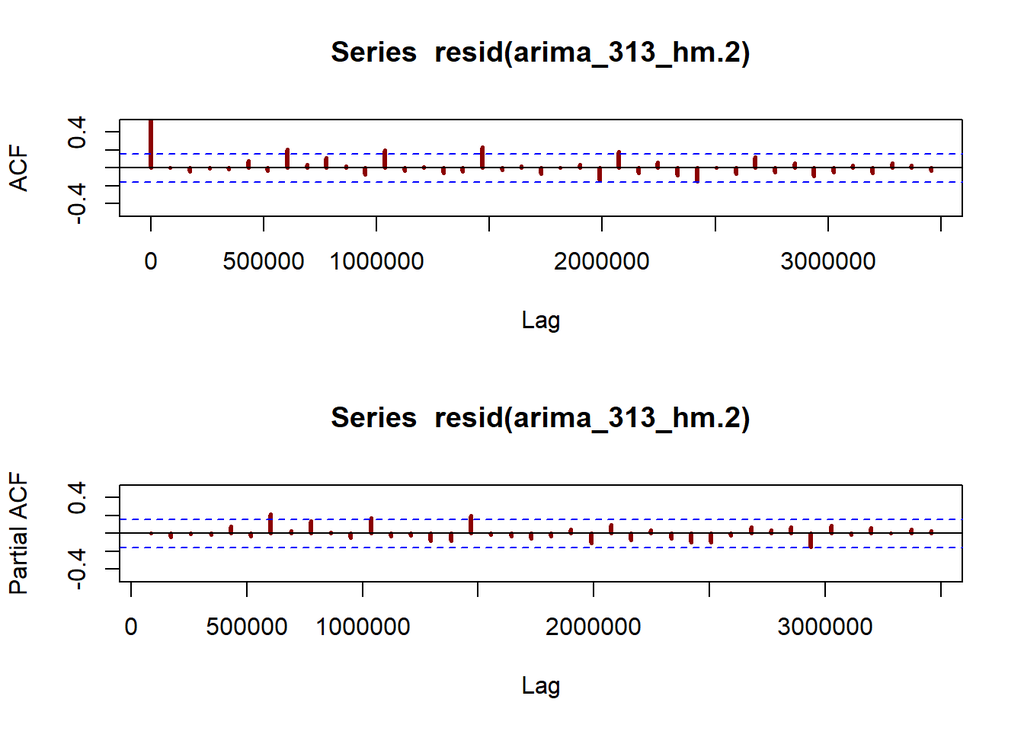

```r
par(mfrow = c(2, 1))
acf(resid(arima_313_hm.2),
    lag.max = 40,
    ylim = c(-0.5, 0.5),
    lwd = 3, col = "darkred",
    na.action = na.pass)
pacf(resid(arima_313_hm.2),
     lag.max =40,
     ylim = c(-0.5, 0.5),
     lwd =3, col = "darkred",
     na.action = na.pass)
```

```r
Box.test(resid(arima_313_hm.2),type = c("Ljung-Box"),lag = 5)
```

```
##
##  Box-Ljung test
##
## data:  resid(arima_313_hm.2)
## X-squared = 1.3259, df = 5, p-value = 0.9322
```

arima_313_hm.2 could work.

- ARIMA(4,1,3)

```r
arima_413_hm <- Arima(heavy_metal.2$heavy_metal,order=c(4,1,3),include.constant = TRUE)
arima_413_hm
```

```
## Series: heavy_metal.2$heavy_metal
## ARIMA(4,1,3) with drift
##
## Coefficients:
##          ar1     ar2      ar3      ar4      ma1      ma2     ma3    drift
##       0.1196  0.5359  -0.3564  -0.1709  -0.6970  -0.5896  0.6408  -0.4657
## s.e.  0.2475  0.2419   0.1233   0.1048   0.2394   0.2952  0.1795   0.1269
##
## sigma^2 = 15.25:  log likelihood = -410.76
## AIC=839.52   AICc=840.81   BIC=866.55
```

```r
coeftest(arima_413_hm)
```

```
##
## z test of coefficients:
##
##       Estimate Std. Error z value  Pr(>|z|)
## ar1    0.11959    0.24754  0.4831 0.6290283
## ar2    0.53585    0.24192  2.2150 0.0267623 *
## ar3   -0.35641    0.12327 -2.8914 0.0038357 **
## ar4   -0.17092    0.10482 -1.6306 0.1029766
## ma1   -0.69701    0.23943 -2.9111 0.0036020 **
## ma2   -0.58965    0.29519 -1.9975 0.0457670 *
## ma3    0.64077    0.17945  3.5707 0.0003561 ***
## drift -0.46575    0.12693 -3.6693 0.0002432 ***
## ---
## Signif. codes:  0 '***' 0.001 '**' 0.01 '*' 0.05 '.' 0.1 ' ' 1
```

```r
arima_413_hm.2 <- Arima(heavy_metal.2$heavy_metal,
                        order=c(4,1,3),
                        fixed=c(NA,NA,NA,NA,0,NA,NA,NA),
                        include.constant = TRUE)
coeftest(arima_413_hm.2)
```

```
##
## z test of coefficients:
##
##        Estimate Std. Error z value  Pr(>|z|)
## ar1   -0.543416   0.080313 -6.7662 1.322e-11 ***
## ar2    0.051420   0.201498  0.2552   0.79858
## ar3   -0.282387   0.143833 -1.9633   0.04961 *
## ar4   -0.222227   0.092161 -2.4113   0.01590 *
## ma2   -0.454845   0.191797 -2.3715   0.01772 *
## ma3    0.157879   0.159063  0.9926   0.32093
## drift -0.460916   0.111871 -4.1201 3.788e-05 ***
## ---
## Signif. codes:  0 '***' 0.001 '**' 0.01 '*' 0.05 '.' 0.1 ' ' 1
```

```r
Box.test(resid(arima_413_hm.2),type = c("Ljung-Box"),lag = 5)
```

```
##
##  Box-Ljung test
##
## data:  resid(arima_413_hm.2)
## X-squared = 0.5464, df = 5, p-value = 0.9903
```

arima_413_hm.2 could work

- ARIMA(1,1,4)

```r
arima_114_hm <- Arima(heavy_metal.2$heavy_metal,order=c(1,1,4),include.constant = TRUE)
arima_114_hm
```

```
## Series: heavy_metal.2$heavy_metal
## ARIMA(1,1,4) with drift
##
## Coefficients:
##          ar1      ma1     ma2      ma3     ma4    drift
##       0.7894  -1.3651  0.3530  -0.0327  0.1537  -0.4744
## s.e.  0.2175   0.2266  0.1846   0.1511  0.0937   0.1597
##
## sigma^2 = 15.11:  log likelihood = -411.11
## AIC=836.21   AICc=837.01   BIC=857.24
```

```r
coeftest(arima_114_hm)
```

```
##
## z test of coefficients:
##
##        Estimate Std. Error z value  Pr(>|z|)
## ar1    0.789436   0.217512  3.6294 0.0002841 ***
## ma1   -1.365099   0.226568 -6.0251  1.69e-09 ***
## ma2    0.353017   0.184550  1.9129 0.0557672 .
## ma3   -0.032700   0.151104 -0.2164 0.8286725
## ma4    0.153746   0.093674  1.6413 0.1007388
## drift -0.474363   0.159743 -2.9695 0.0029825 **
## ---
## Signif. codes:  0 '***' 0.001 '**' 0.01 '*' 0.05 '.' 0.1 ' ' 1
```

```r
Box.test(resid(arima_114_hm),type = c("Ljung-Box"),lag = 5)
```

```
##
##  Box-Ljung test
##
## data:  resid(arima_114_hm)
## X-squared = 0.56554, df = 5, p-value = 0.9895
```

Ljung-Box test shows no autocorrelation in its residuals. So let’s remain arima_114_hm

- ARIMA(4,1,1)

```r
arima_411_hm <- Arima(heavy_metal.2$heavy_metal,order=c(4,1,1),include.constant = TRUE)
arima_411_hm
```

```
## Series: heavy_metal.2$heavy_metal
## ARIMA(4,1,1) with drift
##
## Coefficients:
##           ar1      ar2      ar3      ar4      ma1    drift
##       -0.0762  -0.1406  -0.1905  -0.1154  -0.4746  -0.4609
## s.e.   0.2097   0.1250   0.1034   0.1038   0.2001   0.1105
##
## sigma^2 = 15.51:  log likelihood = -412.93
## AIC=839.86   AICc=840.66   BIC=860.89
```

```r
coeftest(arima_411_hm)
```

```
##
## z test of coefficients:
##
##        Estimate Std. Error z value  Pr(>|z|)
## ar1   -0.076185   0.209674 -0.3633   0.71634
## ar2   -0.140638   0.125039 -1.1247   0.26070
## ar3   -0.190459   0.103355 -1.8428   0.06536 .
## ar4   -0.115358   0.103777 -1.1116   0.26631
## ma1   -0.474596   0.200131 -2.3714   0.01772 *
## drift -0.460882   0.110464 -4.1722 3.016e-05 ***
## ---
## Signif. codes:  0 '***' 0.001 '**' 0.01 '*' 0.05 '.' 0.1 ' ' 1
```

Over half of parameters are insignificant, so we’d better not consider ARIMA(4,1,1).

8. **Let’s use information criteria to make comparison**

```r
AIC(arima_112_hm,arima_114_hm,arima_313_hm.2,arima_311_hm.2,arima_413_hm.2)
```

|  | df | AIC |
| --- | --- | --- |
| arima_112_hm | 5 | 839.4532 |
| arima_114_hm | 7 | 836.2139 |
| arima_313_hm.2 | 5 | 837.5352 |
| arima_311_hm.2 | 3 | 837.9192 |
| arima_413_hm.2 | 8 | 839.8815 |

```r
BIC(arima_112_hm,arima_114_hm,arima_313_hm.2,arima_311_hm.2,arima_413_hm.2)
```

|  | df | BIC |
| --- | --- | --- |
| arima_112_hm | 5 | 854.4730 |
| arima_114_hm | 7 | 857.2415 |
| arima_313_hm.2 | 5 | 852.5549 |
| arima_311_hm.2 | 3 | 846.9310 |
| arima_413_hm.2 | 8 | 863.9131 |

AIC suggests arima_114_hm,and BIC suggests arima_311_hm.2. Let’s forecast with arima_311_hm.2.

9. **Let’ forecast 12-month periods ahead for “heavy metal” by using arima_311_hm.2**

```r
heavy_metal.2
```

```
##            heavy_metal diff
## 2004-01-01         100   NA
## 2004-02-01          96   -4
## 2004-03-01          99    3
## 2004-04-01          98   -1
## 2004-05-01          95   -3
## 2004-06-01          90   -5
## 2004-07-01          91    1
## 2004-08-01          95    4
## 2004-09-01          86   -9
## 2004-10-01          86    0
##        ...
## 2015-09-01          33    0
## 2015-10-01          32   -1
## 2015-11-01          33    1
## 2015-12-01          33    0
## 2016-01-01          30   -3
## 2016-02-01          32    2
## 2016-03-01          28   -4
## 2016-04-01          30    2
## 2016-05-01          32    2
## 2016-06-01          30   -2
```

```r
heavy_metal.2<-heavy_metal.2[,-2]
tail(heavy_metal.2,13)
```

```
##            heavy_metal
## 2015-06-01          31
## 2015-07-01          33
## 2015-08-01          33
## 2015-09-01          33
## 2015-10-01          32
## 2015-11-01          33
## 2015-12-01          33
## 2016-01-01          30
## 2016-02-01          32
## 2016-03-01          28
## 2016-04-01          30
## 2016-05-01          32
## 2016-06-01          30
```

```r
heavy_metal.2.cut<- heavy_metal.2["/2015-06-01",]
tail(heavy_metal.2.cut)
```

```
##            heavy_metal
## 2015-01-01          34
## 2015-02-01          36
## 2015-03-01          35
## 2015-04-01          32
## 2015-05-01          31
## 2015-06-01          31
```

```r
heavy_metal_arima_311 <- Arima(heavy_metal.2.cut$heavy_metal,
                          order=c(3,1,1),
                          fixed=c(0,0,0,NA,NA),
                          include.constant = TRUE)

arima_311.2_forecast <- forecast(heavy_metal_arima_311,
                                 h=12)
arima_311.2_forecast$mean
```

```
## Time Series:
## Start = 11923201
## End = 12873601
## Frequency = 1.15740740740741e-05
##  [1] 30.82379 30.33493 29.84606 29.35720 28.86833 28.37947 27.89060 27.40174
##  [9] 26.91287 26.42401 25.93514 25.44628
```

```r
arima_311.2_forecast$lower[,2]
```

```
## Time Series:
## Start = 11923201
## End = 12873601
## Frequency = 1.15740740740741e-05
##  [1] 22.77829 21.75323 20.75976 19.79288 18.84877 17.92447 17.01759 16.12620
##  [9] 15.24869 14.38372 13.53015 12.68699
```

```r
arima_311.2_forecast$upper[,2]
```

```
## Time Series:
## Start = 11923201
## End = 12873601
## Frequency = 1.15740740740741e-05
##  [1] 38.86930 38.91662 38.93237 38.92152 38.88790 38.83447 38.76362 38.67728
##  [9] 38.57706 38.46430 38.34014 38.20557
```

```r
forecast.data.3 <- data.frame(mean=as.numeric(arima_311.2_forecast$mean),
                            lower=as.numeric(arima_311.2_forecast$lower[,2]),
                            upper=as.numeric(arima_311.2_forecast$upper[,2]))

forecast.data.3.xts <- xts(forecast.data.3,
                         order.by = tail(index(heavy_metal.2),12))

heavy_metal.2.2 <- merge(heavy_metal.2,forecast.data.3.xts)
```

Let’s plot them together in a graph.

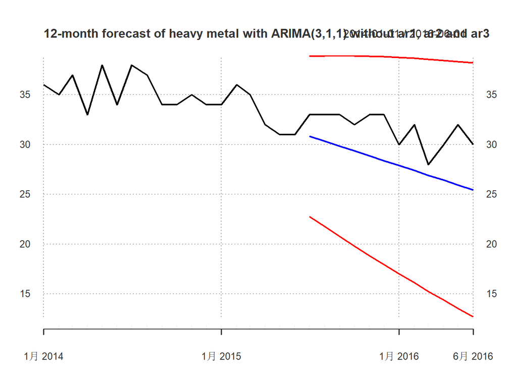

```r
plot(heavy_metal.2.2["2014/",c("heavy_metal","mean","lower","upper")],
     major.ticks = "years",
     grid.ticks.on = "years",
     grid.ticks.lty = 3,
     main = "12-month forecast of heavy metal with ARIMA(3,1,1) without ar1, ar2 and ar3",
     col = c("black", "blue", "red", "red"))
```

Let’s perform error measures

```r
heavy_metal.2.2$mae.heavy_metal<-  abs(heavy_metal.2.2$heavy_metal -heavy_metal.2.2$mean)
heavy_metal.2.2$mse.heavy_metal <-  (heavy_metal.2.2$heavy_metal - heavy_metal.2.2$mean) ^ 2
heavy_metal.2.2$mape.heavy_metal<-  abs((heavy_metal.2.2$heavy_metal - heavy_metal.2.2$mean)/heavy_metal.2.2$heavy_metal)
heavy_metal.2.2$amape.heavy_metal <-  abs((heavy_metal.2.2$heavy_metal - heavy_metal.2.2$mean) /
                                                (heavy_metal.2.2$heavy_metal + heavy_metal.2.2$mean))

dim(heavy_metal.2.2)
```

```
## [1] 150   8
```

```r
error.arima311_heavy_metal <- colMeans(heavy_metal.2.2[,5:8],na.rm = TRUE)
error.arima311_heavy_metal
```

```
##   mae.heavy_metal   mse.heavy_metal  mape.heavy_metal amape.heavy_metal
##        3.44829654       13.68934124        0.10861972        0.05794391
```

## 6.Comparison between VAR and ARIMA models.

1. **For our key words “rock and roll”**

```r
var2_error_measures_rock_and_roll
```

```
##   mae.rock_and_roll   mse.rock_and_roll  mape.rock_and_roll amape.rock_and_roll
##          5.35924784         38.92866996          0.10190290          0.05461636
```

```r
error.arima111
```

```
##   mae.rock_and_roll   mse.rock_and_roll  mape.rock_and_roll amape.rock_and_roll
##          6.40434827         55.38154403          0.13350610          0.06101673
```

```r
compara.1 <- rbind(var2_error_measures_rock_and_roll, error.arima111)
compara.1
```

```
##                                   mae.rock_and_roll mse.rock_and_roll
## var2_error_measures_rock_and_roll          5.359248          38.92867
## error.arima111                             6.404348          55.38154
##                                   mape.rock_and_roll amape.rock_and_roll
## var2_error_measures_rock_and_roll          0.1019029          0.05461636
## error.arima111                             0.1335061          0.06101673
```

Based on comparison above VAR(2,2) is more accurate than arima_111.

2. **For our key words “heavy metal”**

```r
var2_error_measures_heavy_metal
```

```
##   mae.heavy_metal   mse.heavy_metal  mape.heavy_metal amape.heavy_metal
##        1.52230025        2.73201846        0.04851478        0.02434624
```

```r
error.arima311_heavy_metal
```

```
##   mae.heavy_metal   mse.heavy_metal  mape.heavy_metal amape.heavy_metal
##        3.44829654       13.68934124        0.10861972        0.05794391
```

```r
compare.2 <- rbind(var2_error_measures_heavy_metal, error.arima311_heavy_metal )
compare.2
```

```
##                                 mae.heavy_metal mse.heavy_metal
## var2_error_measures_heavy_metal        1.522300        2.732018
## error.arima311_heavy_metal             3.448297       13.689341
##                                 mape.heavy_metal amape.heavy_metal
## var2_error_measures_heavy_metal       0.04851478        0.02434624
## error.arima311_heavy_metal            0.10861972        0.05794391
```

VAR(2,2) is much more accurate than arima_311.

##7.Conclusion

In conclusion,in the data sets we analyzed above, VAR(2,2) can be better than ARIMA models.